# MLNN-Deep-Learning-Report[2]

## CM3015 Machine Learning and Neural Networks

## Enhancing CIFAR-10 Image Classification Using Deep Learning

## 1. Introduction

The report utilizes the Universal Workflow of Machine Learning to produce a model that achieves the best results on the CIFAR-10 dataset. This is achieved through extensive experimentation exclusively using Dense and Dropout layers.

### 1.1 Background and Motivation

In the realm of computer vision, deep learning techniques have demonstrated remarkable performance in tasks such as image classification. The CIFAR-10 dataset, curated by Alex Krizhevsky, Vinod Nair, and Geoffrey Hinton, consisting of 60,000 32x32 color images across 10 classes, serves as a benchmark for evaluating the effectiveness of such techniques.Our motivation lies in exploring various methodologies to enhance image classification accuracy on this dataset.

### 1.3 Overview of the CIFAR-10 Dataset

The CIFAR-10 dataset comprises 60,000 color images divided into 10 classes, each containing 6,000 images. The dataset is further partitioned into 50,000 training images and 10,000 test images. Notably, the images are relatively low-resolution, with dimensions of 32x32 pixels, posing unique challenges for classification algorithms.

Source: https://www.kaggle.com/datasets/ekaakurniawan/the-cifar10-dataset, The CIFAR-10 dataset used in this project was obtained from Kaggle. I acknowledge the contribution of Alex Krizhevsky in creating the dataset.

## 2. Methodology

### 2.1 Defining Hyperparameters

In this section, we define the default hyperparameters used for training the models. These hyperparameters include:

- Epochs: The number of iterations over the entire dataset during training.
- Batch Size: The number of samples processed before the model is updated.

These hyperparameters are crucial for controlling the training process and can significantly impact the performance and convergence of the model. By setting default values and allowing them to be overridden, the experimentation process becomes more flexible and adaptable to different scenarios.

```python
# Define default hyperparameters for training
train_hyperparams = {
    'epochs': 100,      # Number of training epochs
    'batch_size': 512   # Batch size for training data
}

# This dictionary holds default hyperparameters for training.
# 'epochs' specifies the number of iterations over the entire dataset during training.
# 'batch_size' determines the number of samples to be processed in one iteration.

# These default hyperparameters can be overridden by passing keyword arguments
# to the constructor of the experiment class.
```

### 2.2 Environment Setup

By setting up the environment in this way, the notebook ensures reproducibility and facilitates collaboration by clearly documenting the dependencies and configurations required to run the experiments.

### Installation of Dependencies

```python
# Installs the matplotlib library for data visualization
!pip install matplotlib

# Installs the tensorflow library for building and training machine learning models
!pip install tensorflow

# Installs or updates the tfds-nightly library for accessing TensorFlow Datasets, ensuring it's the latest version
!pip install -U tfds-nightly

# Installs or updates the tqdm library, which provides a progress bar for iterative processes
!pip install -U tqdm

# Installs the hashlib library for cryptographic hash functions
#!pip install hashlib

# Install the typing-extensions module for supporting type hints in Python 3.6 and 3.7
#!pip install typing-extensions
```

### Importing Libraries

TensorFlow and TensorFlow Datasets are imported, along with specific modules from Keras for building neural network models.

```python
import tensorflow as tf
import tensorflow_datasets as tfds
from tensorflow.keras import (
    models,          # Importing models module from Keras for building neural network models
    layers,          # Importing layers module from Keras for defining layers in neural networks
    losses,          # Importing losses module from Keras for defining loss functions
    optimizers,      # Importing optimizers module from Keras for configuring optimization algorithms
    regularizers,    # Importing regularizers module from Keras for applying regularization techniques
    callbacks,       # Importing callbacks module from Keras for defining callback functions during training
)
```

[output not shown]

### Version Information

```python
# print("TensorFlow version:", tf.__version__)
# print("Keras version:", keras.__version__)
# print("TensorFlow Datasets version:", tfds.__version__)
```

### Additional Imports

Various Python modules and libraries are imported, including NumPy for numerical computations and Matplotlib for data visualization.

```python
from typing import List, Dict, Tuple, Callable, Union, Optional, Any
```

```python
import functools     # Importing the functools module, which provides higher-order functions and operations on callable objects
import itertools     # Importing the itertools module, which provides functions for creating iterators for efficient looping
import os            # Importing the os module, which provides a portable way to interact with the operating system

import numpy as np  # Importing the numpy module with an alias 'np', which provides support for numerical computing

import matplotlib.pyplot as plt       # Importing the pyplot module from matplotlib with an alias 'plt', which provides a MATLAB-like plotting interface
from matplotlib.ticker import PercentFormatter  # Importing the PercentFormatter class from the ticker module within matplotlib, used for formatting tick labels with percentage formatting
```

```python
# Navigate to the "MLNN" folder
folder_path = "C:\\Users\\lavan\\Desktop\\MLNLP"
```

### 2.3 Defining the Problem & Assembling the Dataset

Classifying raw images into categories is a fundamental task in computer vision with widespread applications across various industries. At its core, image classification aims to assign a single class label to an input image based on its visual content. This task falls under the domain of multi-class, single-label classification problems, where each image belongs to one of several predefined categories.

Formally, the process of image classification involves mapping an input image X to a predicted class label y using a model g parameterized by trainable parameters theta. Mathematically, this can be expressed as:

$\hat{y} = f(X) = \textbf{argmax } g(\theta, X)_{[k]}, \forall{k \in K=\{ 0...|classes| \}}$, where:

- $X$ is the input image
- $f$ is the labeller function
- $g$ is the model
- $\theta$ are the trainable parameters of the model

The present project focuses on utilizing the CIFAR-10 dataset, a well-known benchmark dataset widely used in the field of computer vision. The CIFAR-10 dataset, available in the TensorFlow Datasets Catalog, serves as an illustrative example of an image classification problem.

It consists of a collection of 60,000 32x32 color images distributed across 10 distinct classes, with each class containing 6,000 images. Specifically, the dataset comprises 50,000 training images and 10,000 test images, facilitating the evaluation of classification models.

### Loading CIFAR-10 Dataset

Below is the Python code snippet used to load the CIFAR-10 dataset and retrieve relevant information about its structure and characteristics:

```python
# Load CIFAR-10 dataset with information
ds, ds_info = tfds.load("cifar10", with_info=True)
```

```python
# Compute image dimensions
ds_image_dims = functools.reduce(lambda x, y: x * y, ds_info.features["image"].shape)
print('ds_image_dims =', ds_image_dims)
```

```
ds_image_dims = 3072
```

```python
# Retrieve number of classes
ds_classes = ds_info.features["label"].num_classes
print('ds_classes =', ds_classes)
```

```
ds_classes = 10
```

```python
# Display dataset description
ds_description = ds_info.description
print(ds_description)
```

```
The CIFAR-10 dataset consists of 60000 32x32 colour images in 10 classes, with 6000 images per class. There are 50000 training images and 10000 test images.
```

```python
# Display a sample of the training data
tfds.as_dataframe(ds["train"].take(10), ds_info)
```

|  | id | image | label |
| --- | --- | --- | --- |
| 0 | train_16399 |  | 7 (horse) |
| 1 | train_01680 |  | 8 (ship) |
| 2 | train_47917 |  | 4 (deer) |
| 3 | train_17307 |  | 4 (deer) |
| 4 | train_27051 |  | 6 (frog) |
| 5 | train_48736 |  | 5 (dog) |
| 6 | train_26263 |  | 2 (bird) |
| 7 | train_01456 |  | 9 (truck) |
| 8 | train_19135 |  | 6 (frog) |
| 9 | train_31598 |  | 6 (frog) |

This code segment demonstrates the process of loading the CIFAR-10 dataset using TensorFlow Datasets. It extracts information such as the image dimensions, the number of classes, and displays a brief overview of the dataset's contents.

### 2.4 Measure of Success

The effectiveness of a classification model is typically assessed using appropriate metrics that quantify its performance. In the context of the CIFAR-10 dataset, where the classes are balanced with an equal number of examples per class, accuracy serves as a suitable metric for evaluating model performance. Accuracy measures the proportion of correctly classified instances out of the total number of instances.

Mathematically, accuracy is calculated using the formula:

$Accuracy = \frac{Correct}{Total} = \frac{TP + TN}{TP + FP + TN + FN}$

where:

- TP represents true positive predictions.
- TN represents true negative predictions.
- FP represents false positive predictions.
- FN represents false negative predictions.

Additionally, to train a classification model, a suitable loss function is required to quantify the difference between predicted and actual class labels. Cross-entropy loss is commonly used for this purpose, especially in scenarios where the output of the model is a probability distribution over the classes. It measures the dissimilarity between the true probability distribution of the labels and the predicted probability distribution.

Mathematically, cross-entropy loss is calculated using the formula:

$CCE = L(y, \hat{y}) = -\sum^{N}_{n=1}\sum^{K}_{k=1} y_{nk} \log{\hat{y}_{nk}}$, where:

- $y$ is a vector representing the one-hot encoded true label.
- $\hat{y}$ is a vector representing the predicted probability distribution.
- $N$ is the number of instances.
- $K$ is the number of classes.

It is important to note that when using the categorical cross-entropy loss function, the true labels must be one-hot encoded. Alternatively, the sparse categorical cross-entropy loss function can be used, which does not require prior one-hot encoding of labels.

Below is a Python code snippet demonstrating the computation of categorical cross-entropy loss using TensorFlow:

```python
# Initialize categorical cross-entropy loss
cce = losses.CategoricalCrossentropy()

# Sample predictions and ground truth labels
y_true_1 = np.array([0.0, 0.0, 1.0, 0.0])  # Ground truth: [0, 0, 1, 0]
y_pred_1 = np.array([0.0, 0.0, 1.0, 0.0])  # Correct predictions

y_true_2 = np.array([0.0, 0.0, 1.0, 0.0])  # Ground truth: [0, 0, 1, 0]
y_pred_2 = np.array([0.0, 1.0, 0.0, 0.0])  # Incorrect predictions, predicted class is index 1

y_true_3 = np.array([0.0, 0.0, 1.0, 0.0])  # Ground truth: [0, 0, 1, 0]
y_pred_3 = np.array([0.0, 0.5, 0.5, 0.0])  # Partially correct predictions

# Calculate loss for each set of predictions
loss_1 = cce(y_true=y_true_1, y_pred=y_pred_1)
loss_2 = cce(y_true=y_true_2, y_pred=y_pred_2)
loss_3 = cce(y_true=y_true_3, y_pred=y_pred_3)

# Display
print("Loss 1:", loss_1.numpy())
print("Loss 2:", loss_2.numpy())
print("Loss 3:", loss_3.numpy())
```

[output not shown]

[output not shown]

```
Loss 1: 1.0000000494736474e-07
Loss 2: 16.11809565095832
Loss 3: 0.6931471805599453
```

### 2.5 Evaluation Protocol

Hold-out test sets are an optimal strategy when the dataset is substantial, as is the case with the CIFAR10 dataset, which includes 10,000 data points exclusively for model evaluation.

Given this, the Evaluation Protocol chosen for this work is the Hold-out validation set.

The evaluation process follows these steps:

#### 1. Dataset Splitting

- The CIFAR10 dataset consists of 50,000 labeled examples in the CIFAR10_train split.
- This split is further divided into two subsets: 80% for training (CIFAR10_train_train) and 20% for validation (CIFAR10_train_valid).

#### 2. Training and Validation

- During training, the model is trained on the CIFAR10_train_train split and validated on the CIFAR10_train_valid split.
- The model's accuracy and loss are continuously monitored against both training and validation data during training.

#### 3. Hyperparameter Tuning

- Hyperparameters are tuned to prevent overfitting on the training split and to achieve the best accuracy on the validation split.
- The best hyperparameters and model architecture are determined based on the lowest loss on the validation split.

#### 4. Retraining

- The best model architecture and hyperparameters are retrained from scratch using the entire CIFAR10_train split (train + valid) for the number of epochs that performed best during validation.

#### 5. Final Evaluation

- The model is evaluated on the held-out CIFAR10_test split, which was never used during training or validation.
- The accuracy score on the CIFAR10_test split confirms whether the model generalizes well to unseen data.

```python
# Length of each split
[
    len(ds)
    for ds in tfds.load("cifar10", split=("train[:80%]", "train[80%:]", "test"), as_supervised=True)
]
```

```
[40000, 10000, 10000]
```

```python
# Functions to access different splits of the dataset
def get_training_data() -> tfds.Split:
    """
    Returns the first 80% split of the CIFAR10_train dataset for training.
    """
    return tfds.load("cifar10", split="train[:80%]", as_supervised=True)

def get_validation_data() -> tfds.Split:
    """
    Returns the last 20% split of the CIFAR10_train dataset for validation.
    """
    return tfds.load("cifar10", split="train[80%:]", as_supervised=True)

def get_training_and_validation_data() -> tfds.Split:
    """
    Returns the entire CIFAR10_train dataset for final training.
    """
    return tfds.load("cifar10", split="train", as_supervised=True)

def get_test_data() -> tfds.Split:
    """
    Returns the entire CIFAR10_test dataset for final testing.
    """
    return tfds.load("cifar10", split="test", as_supervised=True)
```

## 3. Data Preprocessing & Preparation

### 3.1 Data Cleaning and Preprocessing Techniques

Data cleaning and preprocessing are crucial steps to ensure the quality and consistency of the dataset before training a machine learning model. In the context of the CIFAR-10 dataset, which consists of images, several preprocessing techniques can be applied to enhance the effectiveness of the model.

### Removing Duplicate Images

This step aims to ensure that there are no duplicate images in the dataset, which could bias the model during training. The code iterates through the images, computes their hash values, and removes duplicates based on these hash values. The shapes of the original and cleaned datasets are printed for verification.

```python
import cv2
from tensorflow.keras.datasets import cifar10
import hashlib

# Load CIFAR-10 dataset
(train_images, train_labels), (test_images, test_labels) = cifar10.load_data()

# Combine train and test sets for preprocessing
images = np.concatenate([train_images, test_images])
labels = np.concatenate([train_labels, test_labels])

# Convert images to C-contiguous format
images = np.ascontiguousarray(images)

# Step 1: Remove duplicate images
hashes = [hashlib.md5(img).digest() for img in images]
unique_hashes = set()
duplicate_indices = []
for i, h in enumerate(hashes):
    if h in unique_hashes:
        duplicate_indices.append(i)
    else:
        unique_hashes.add(h)

clean_images = np.delete(images, duplicate_indices, axis=0)
clean_labels = np.delete(labels, duplicate_indices, axis=0)

# Here, we are just printing the shapes to verify the removal of duplicates
print("Original Dataset Shapes:")
print("Images:", images.shape)
print("Labels:", labels.shape)

print('')

print("Cleaned Dataset Shapes:")
print("Images:", clean_images.shape)
print("Labels:", clean_labels.shape)
```

```
Original Dataset Shapes:
Images: (60000, 32, 32, 3)
Labels: (60000, 1)

Cleaned Dataset Shapes:
Images: (60000, 32, 32, 3)
Labels: (60000, 1)
```

### Gray Scale Conversion

After removing duplicates, the code converts the cleaned images to grayscale. This is done using OpenCV's cv2.cvtColor function. Grayscale conversion reduces the complexity of the data while preserving relevant features.

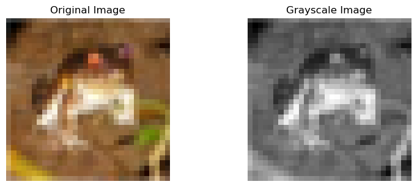

```python
# Step 2: Grayscale conversion
gray_images = [cv2.cvtColor(img, cv2.COLOR_RGB2GRAY) for img in clean_images]

# Display the original and preprocessed images
plt.figure(figsize=(12, 6))
plt.subplot(2, 3, 1)
plt.imshow(clean_images[0])
plt.title('Original Image')
plt.axis('off')

plt.subplot(2, 3, 2)
plt.imshow(gray_images[0], cmap='gray')
plt.title('Grayscale Image')
plt.axis('off')

plt.tight_layout()
plt.show()
```

### Noise Reduction (Gaussian Blur)

Gaussian blur is applied to the grayscale images using OpenCV's cv2.GaussianBlur function. This step helps reduce noise in the images, which can improve the model's ability to detect important features.

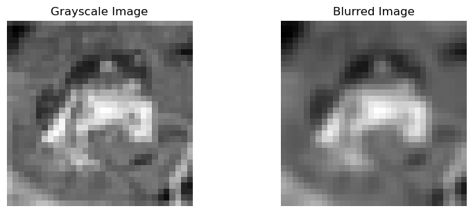

```python
# Step 3: Noise reduction (Gaussian blur)
blurred_images = [cv2.GaussianBlur(img, (3, 3), 0) for img in gray_images]

plt.figure(figsize=(12, 6))
plt.subplot(2, 3, 1)
plt.imshow(gray_images[0], cmap='gray')
plt.title('Grayscale Image')
plt.axis('off')

plt.subplot(2, 3, 2)
plt.imshow(blurred_images[0], cmap='gray')
plt.title('Blurred Image')
plt.axis('off')

plt.tight_layout()
plt.show()
```

### Contrast Enhancement (Histogram Equalization)

Histogram equalization is applied to the blurred images using OpenCV's cv2.equalizeHist function. This technique normalizes the intensity distribution of pixel values across images, improving overall image quality and enhancing feature extraction.

```
(-0.5, 31.5, 31.5, -0.5)
```

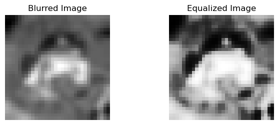

```python
# Step 4: Contrast enhancement (Histogram equalization)
equalized_images = [cv2.equalizeHist(img) for img in blurred_images]

plt.figure(figsize=(12, 6))
plt.subplot(2, 3, 1)
plt.imshow(blurred_images[0], cmap='gray')
plt.title('Blurred Image')
plt.axis('off')

plt.subplot(2, 3, 2)
plt.imshow(equalized_images[0], cmap='gray')
plt.title('Equalized Image')
plt.axis('off')
```

### Edge Detection (Canny Edge Detector)

Canny edge detection is applied to the equalized images using OpenCV's cv2.Canny function. This step highlights boundaries and shapes within the images, which can be useful for object detection tasks.

```
(-0.5, 31.5, 31.5, -0.5)
```

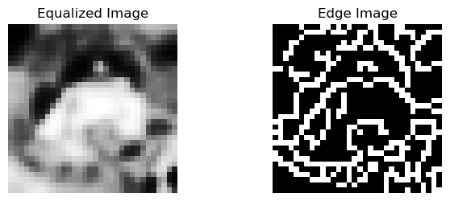

```python
# Step 5: Edge detection (Canny edge detector)
edge_images = [cv2.Canny(img, 100, 200) for img in equalized_images]

plt.figure(figsize=(12, 6))
plt.subplot(2, 3, 1)
plt.imshow(equalized_images[0], cmap='gray')
plt.title('Equalized Image')
plt.axis('off')

plt.subplot(2, 3, 2)
plt.imshow(edge_images[0], cmap='gray')
plt.title('Edge Image')
plt.axis('off')
```

### 3.2 Normalization and Standardization

Normalization and standardization are essential preprocessing steps to ensure that features have similar scales and distributions, which can improve the convergence and performance of machine learning models.

### Normalization

Normalization scales feature values to a range between 0 and 1. The normalization formula typically involves subtracting the minimum value from each feature and then dividing by the range (the difference between the maximum and minimum values). This process ensures that all feature values fall within the same numerical range, making them comparable and preventing features with larger scales from dominating the model's training process.

```python
from sklearn.preprocessing import MinMaxScaler, StandardScaler

# Perform normalization
scaler = MinMaxScaler()
images_normalized = scaler.fit_transform(images.reshape(-1, 32*32*3)).reshape(images.shape)
```

### Standardization

This process transforms feature values to have a mean of 0 and a standard deviation of 1. It helps center the data around zero and unit variance. Standardization is particularly useful when the features have different scales or follow a normal distribution.

```python
# Perform standardization
scaler = StandardScaler()
images_standardized = scaler.fit_transform(images.reshape(-1, 32*32*3)).reshape(images.shape)
```

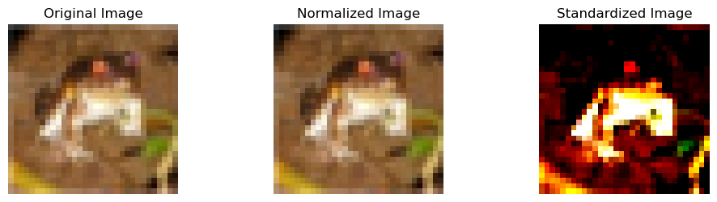

```python
# Display the original and preprocessed images
plt.figure(figsize=(12, 6))
plt.subplot(2, 3, 1)
plt.imshow(images[0])
plt.title('Original Image')
plt.axis('off')

# Ensure pixel values are in the [0, 1] range for normalized images
normalized_image = images_normalized[0]
normalized_image = normalized_image.clip(0, 1)  # Clip values outside [0, 1]
plt.subplot(2, 3, 2)
plt.imshow(normalized_image)
plt.title('Normalized Image')
plt.axis('off')

# Ensure pixel values are in the [0, 1] range for standardized images
standardized_image = images_standardized[0]
standardized_image = standardized_image.clip(0, 1)  # Clip values outside [0, 1]
plt.subplot(2, 3, 3)
plt.imshow(standardized_image)
plt.title('Standardized Image')
plt.axis('off')

plt.show()
```

### 3.2 Data Preparation

This code defines a Preprocessor class that preprocesses images and labels of the dataset. The purpose of this class is to transform the input images from their original format (32x32x3) into a flattened format (3072x1) and to one-hot encode the labels.

The preprocessing steps include:

1. Scaling the RGB values of each image to the range [0, 1].
2. Flattening the three RGB channels (32x32x3) into a single feature vector (3072x1).
3. One-hot encoding the categorical labels, where all negative classes are marked as 0 and the positive class is marked as 1.

```python
import tensorflow as tf

class Preprocessor:
    """
    Preprocesses the images of the dataset.

    :param image_dims: The number of pixels in the image (e.g., 32 * 32 * 3 for CIFAR-10).
    :param n_classes: The number of classes in the dataset.
    :return: A callable that takes an image and a label and preprocesses them.
    """

    def __init__(self, image_dims: int, n_classes: int):
        """
        Initializes the Preprocessor with image dimensions and number of classes.
        :param image_dims: The number of pixels in the image.
        :param n_classes: The number of classes in the dataset.
        """
        self.image_dims = image_dims
        self.n_classes = n_classes

    def __call__(self, image: tf.Tensor, label: tf.Tensor) -> tf.Tensor:
        """
        Performs preprocessing on the input image and label.
        :param image: The image tensor to preprocess.
        :param label: The label tensor to preprocess.
        :return: The preprocessed image and label tensors.
        """
        # If image data type is uint8 (8-bit unsigned integer), convert it to float32 and scale RGB values to [0, 1]
        if image.dtype == tf.uint8:
            image = tf.cast(image, tf.float32) / 255.0
            # Reshape image tensor to a flattened format
            image = tf.reshape(image, (self.image_dims,))
        # If label data type is int64 (64-bit integer), one-hot encode the labels
        if label.dtype == tf.int64:
            label = tf.one_hot(label, self.n_classes)
        return image, label
```

```python
preprocessing_fn = Preprocessor(image_dims=ds_image_dims, n_classes=ds_classes)
preprocessing_fn
```

```
<__main__.Preprocessor at 0x1a5d7d14f10>
```

### 5. Baseline Model

The baseline model serves as the initial benchmark for performance evaluation in image classification tasks using the CIFAR-10 dataset. This model is designed to be simple yet effective enough to outperform a random classifier, providing a starting point for further model development and optimization.

### 5.1 Model Architecture

The baseline model is a feedforward neural network with a single hidden layer. It uses the Rectified Linear Unit (ReLU) activation function for the hidden layer and the softmax activation function for the output layer, which is typical for multi-class classification tasks. The number of units in the hidden layer is set to 10, corresponding to the number of classes in the CIFAR-10 dataset.

```python
# Import necessary libraries and modules
from matplotlib.ticker import PercentFormatter
import itertools
import os

# Define the ModelBuilder class for constructing neural network models
class ModelBuilder:
    """
    Builder class for the Image Classification Model that minimizes
    a cross-entropy loss function (default) against the n_classes possible
    classes in the dataset, with the output head being a softmax layer.
    """

    # Define default optimizer, loss function, and other attributes
    optimizer: Union[str, optimizers.Optimizer] = "rmsprop"
    loss: Union[str, losses.Loss] = "categorical_crossentropy"
    log_dir_tensorboard: Optional[str] = None
    log_path_training: Optional[str] = None
    layers: List[
        Tuple[
            int,
            Optional[Union[str, Callable[[tf.Tensor], tf.Tensor]]],
            Optional[Union[str, regularizers.Regularizer]],
            Optional[float],
        ]
    ] = None

    def __init__(
        self,
        input_dims: int,
        n_classes: int,
    ):
        self.input_dims = input_dims
        self.n_classes = n_classes
        self.layers = []

    # Method to add a layer to the model
    def add_layer(
        self,
        units: int,
        activation: Optional[Union[str, Callable[[tf.Tensor], tf.Tensor]]] = None,
        regularization: Optional[Union[str, regularizers.Regularizer]] = None,
        dropout: Optional[float] = None,
    ) -> "ModelBuilder":
        """
        Adds a layer to the model.
        """
        self.layers.append((units, activation, regularization, dropout))
        return self

    # Method to set the optimizer
    def with_optimizer(
        self,
        optimizer: Union[str, optimizers.Optimizer],
    ) -> "ModelBuilder":
        """
        Sets the optimizer to use for training, or reverts to the default.
        """
        self.optimizer = optimizer
        return self

    # Method to set the loss function
    def with_loss(
        self,
        loss: Union[str, losses.Loss],
    ) -> "ModelBuilder":
        """
        Sets the loss function to use for training, or reverts to the default.
        """
        self.loss = loss
        return self

    # Method to build the model
    def build(self) -> models.Sequential:
        """
        Resets the tensorflow random seed, builds the model, compiles it,
        prints a summary of the model, and returns the model.
        """
        tf.keras.utils.set_random_seed(42)
        model = models.Sequential()
        for i, (u, a, r, d) in enumerate(self.layers):
            if i == 0:
                model.add(
                    layers.Dense(
                        u,
                        activation=a,
                        kernel_regularizer=r,
                        input_shape=(self.input_dims,),
                        name=f"x{i}",
                    )
                )
            else:
                model.add(
                    layers.Dense(
                        u,
                        activation=a,
                        kernel_regularizer=r,
                        name=f"x{i}",
                    )
                )
            if d is not None and d > 0.0:
                model.add(layers.Dropout(d))
        model.add(layers.Dense(self.n_classes, activation="softmax", name="y_hat"))
        model.compile(optimizer=self.optimizer, loss=self.loss, metrics=["acc"])
        model.summary()
        return model
```

### Experimental Setup

The code also includes classes for conducting experiments in a standardized manner. The 'ModelBuilder' class facilitates the construction of neural network models with customizable architectures, while the 'Experiment' class orchestrates the training and evaluation process. The 'plot_history' function is provided for visualizing the training and validation performance over epochs.

```python
# Define the Experiment class for conducting experiments
class Experiment:
    """
    Builds an experiment setup to the default hyperparameters, and
    run it against a given model, dataset, and preprocessor.
    """

    # Define attributes and initialize experiment setup
    train_data: tfds.Split
    valid_data: Optional[tfds.Split] = None
    preprocessor: Optional[Preprocessor] = None
    log_tensorboard_dirpath: Optional[str] = None
    log_csv_filepath: Optional[str] = None

    def __init__(self, default_hyperparams: Dict[str, Any], **kwargs):
        self.batch_size = kwargs.get("batch_size", default_hyperparams["batch_size"])
        assert self.batch_size > 0, "The `batch_size` must be greater than zero."
        self.epochs = kwargs.get("epochs", default_hyperparams["epochs"])
        assert self.batch_size > 1, "The `epochs` must be greater than 1."

    # Method to set the preprocessor
    def with_preprocessor(self, preprocessor: Optional[Preprocessor]) -> "Experiment":
        """
        Sets the preprocessor to use for training, or reverts to the default.
        """
        self.preprocessor = preprocessor
        return self

    # Method to set the model
    def with_model(self, model: models.Sequential) -> "Experiment":
        """
        Sets the model to use for training.
        """
        self.model = model
        return self

    # Method to set the training data
    def with_train_data(self, split: tfds.Split) -> "Experiment":
        """
        Sets the training data to use for training.
        """
        self.train_data = split
        return self

    # Method to set the validation data
    def with_valid_data(self, split: Optional[tfds.Split]) -> "Experiment":
        """
        Sets the validation data to use for validation.
        """
        self.valid_data = split
        return self

    # Method to enable logging to TensorBoard
    def enable_log_tensorboard(self, dirpath: str) -> "Experiment":
        """
        Enables logging to TensorBoard and sets the directory path to use.
        """
        self.log_tensorboard_dirpath = dirpath
        return self

    # Method to enable logging to CSV
    def enable_log_csv(self, filepath: str) -> "Experiment":
        """
        Enables logging to CSV and sets the file path to use.
        """
        filedir = os.path.dirname(filepath)
        if not os.path.isdir(filedir):
            os.makedirs(filedir)
        self.log_csv_filepath = filepath
        return self

    # Method to run the experiment
    def run(self) -> callbacks.History:
        """
        Runs the experiment, pre-processing the data if a preprocessor is set,
        and logging to TensorBoard and CSV if enabled.
        """
        assert self.model, "The `model` is required."
        assert self.train_data, "The `train_data` is required."
        train_xy = self.train_data
        valid_xy = self.valid_data
        if self.preprocessor:
            train_xy = train_xy.map(self.preprocessor)
            if valid_xy:
                valid_xy = valid_xy.map(self.preprocessor)
        train_xy = train_xy.cache().batch(self.batch_size)
        if valid_xy:
            valid_xy = valid_xy.cache().batch(self.batch_size)
        tf.keras.utils.set_random_seed(42)
        return self.model.fit(
            train_xy,
            epochs=self.epochs,
            batch_size=self.batch_size,
            validation_data=valid_xy,
            callbacks=self._build_callbacks(),
        )

    # Method to build callbacks for logging
    def _build_callbacks(self) -> Optional[List[callbacks.Callback]]:
        fit_callbacks = None
        if self.log_tensorboard_dirpath or self.log_csv_filepath:
            fit_callbacks = []
            if self.log_tensorboard_dirpath:
                fit_callbacks.append(
                    callbacks.TensorBoard(
                        log_dir=self.log_tensorboard_dirpath, write_graph=True, write_images=True
                    )
                )
            if self.log_csv_filepath:
                fit_callbacks.append(callbacks.CSVLogger(filename=self.log_csv_filepath))
        return fit_callbacks
```

### Training and Validation History

[output not shown]

[output not shown]

```
Model: "sequential"
_________________________________________________________________
 Layer (type)                Output Shape              Param #
=================================================================
 x0 (Dense)                  (None, 10)                30730

 y_hat (Dense)               (None, 10)                110

=================================================================
Total params: 30840 (120.47 KB)
Trainable params: 30840 (120.47 KB)
Non-trainable params: 0 (0.00 Byte)
_________________________________________________________________
WARNING:tensorflow:From C:\Users\lavan\anaconda3\Lib\site-packages\keras\src\utils\tf_utils.py:492: The name tf.ragged.RaggedTensorValue is deprecated. Please use tf.compat.v1.ragged.RaggedTensorValue instead.
```

[output not shown]

[output not shown]

[output not shown]

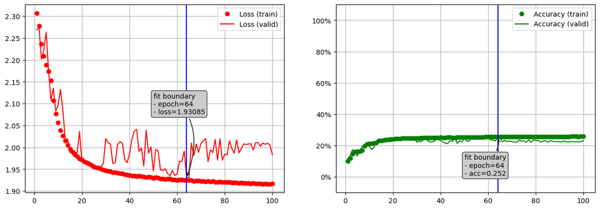

```python
# Define a function to plot the training and validation history
def plot_history(history: callbacks.History) -> None:
    metrics = history.history
    acc_train, acc_valid = metrics["acc"], metrics["val_acc"]
    loss_train, loss_valid = metrics["loss"], metrics["val_loss"]
    x = range(1, len(acc_train) + 1)
    fit = np.argmin(loss_valid)

    _, axes = plt.subplots(nrows=1, ncols=2, sharex=True, sharey=False, figsize=(15, 5))
    axes[0].plot(x, loss_train, "ro", label="Loss (train)")
    axes[0].plot(x, loss_valid, "r", label="Loss (valid)")
    axes[0].annotate(
        f"fit boundary\n- epoch={fit}\n- loss={round(loss_valid[fit], 5)}",
        xy=(fit, loss_valid[fit]),
        xytext=(
            len(acc_train) * 0.5,
            max(itertools.chain(*[loss_train, loss_valid])) * 0.9,
        ),
        bbox=dict(boxstyle="round", fc="#ccc", ec="#444"),
        arrowprops=dict(
            facecolor="black",
            arrowstyle="->",
            connectionstyle="angle3,angleA=-45,angleB=70",
        ),
    )
    axes[1].set_ylim(-0.1, 1.1)
    axes[1].plot(x, acc_train, "go", label="Accuracy (train)")
    axes[1].plot(x, acc_valid, "g", label="Accuracy (valid)")
    axes[1].yaxis.set_major_formatter(PercentFormatter(xmax=1.0, decimals=0))
    axes[1].annotate(
        f"fit boundary\n- epoch={fit}\n- acc={round(acc_valid[fit], 5)}",
        xy=(fit, acc_valid[fit]),
        xytext=(
            len(acc_train) * 0.5,
            min(itertools.chain(*[acc_train, acc_valid])) * 0.1,
        ),
        bbox=dict(boxstyle="round", fc="#ccc", ec="#444"),
        arrowprops=dict(
            facecolor="black",
            arrowstyle="->",
            connectionstyle="angle3,angleA=45,angleB=-70",
        ),
    )
    for ax in axes:
        ax.axvline(fit, color="b")
        ax.legend()
        ax.grid()

# Run the baseline model experiment and plot the history
plot_history(
    Experiment(train_hyperparams)
    .with_preprocessor(preprocessing_fn)
    .with_train_data(get_training_data())
    .with_valid_data(get_validation_data())
    .with_model(
        ModelBuilder(input_dims=ds_image_dims, n_classes=ds_classes)
        .add_layer(10, activation="relu")
        .build()
    )
    .run()
)
```

The baseline model was trained using a feedforward neural network architecture with a single hidden layer consisting of 10 units. The training was conducted for 100 epochs with a batch size of 512. Below are the key training metrics observed during the training process:

**Training Loss:** Started at 2.3070 and gradually decreased to 1.9159.

**Training Accuracy:** Started at 9.88% and increased to 25.84%.

**Validation Loss:** Started at 2.2689 and fluctuated throughout training, eventually reaching 1.9891.

**Validation Accuracy:** Started at 11.57% and increased to 23.05%.

These results indicate that while the model's performance improved over the course of training, it still exhibits limited predictive power. Further model iterations and optimization techniques may be necessary to achieve higher accuracy on the CIFAR-10 dataset.

### 6. Scalling Up: Overfitting Model

To create a model that overfits the train split, we can experiment with models with larger capacities. This typically involves increasing the number of layers and/or the number of units in each layer. Let's start by visualizing the training and validation accuracy of the models experimented upon during part 5. This will help us understand the current performance before attempting to overfit the training data.

[output not shown]

We can see that as the model capacity increases, the training accuracy tends to improve while the validation accuracy may decrease, indicating potential overfitting.

Next, we can proceed with experimenting on models with even larger capacities to intentionally induce overfitting on the training data. We can add more layers or increase the number of units in existing layers. After training these models, we can observe the behavior of the training and validation accuracy curves to confirm overfitting.

### Model 1: 256 Units Per Layer

```
Model: "sequential_1"
_________________________________________________________________
 Layer (type)                Output Shape              Param #
=================================================================
 x0 (Dense)                  (None, 256)               786688

 x1 (Dense)                  (None, 256)               65792

 y_hat (Dense)               (None, 10)                2570

=================================================================
Total params: 855050 (3.26 MB)
Trainable params: 855050 (3.26 MB)
Non-trainable params: 0 (0.00 Byte)
_________________________________________________________________
```

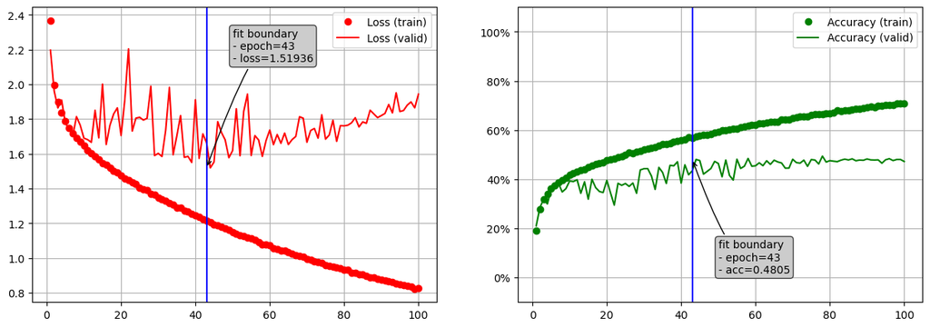

```python
plot_history(
    Experiment(train_hyperparams)
    .with_preprocessor(preprocessing_fn)
    .with_train_data(get_training_data())
    .with_valid_data(get_validation_data())
    .with_model(
        ModelBuilder(input_dims=ds_image_dims, n_classes=ds_classes)
        .add_layer(256, activation="relu")
        .add_layer(256, activation="relu")
        .build()
    )
    .run()
)
```

### Model 2: 512 Units Per Layer

```
Model: "sequential_2"
_________________________________________________________________
 Layer (type)                Output Shape              Param #
=================================================================
 x0 (Dense)                  (None, 512)               1573376

 x1 (Dense)                  (None, 512)               262656

 y_hat (Dense)               (None, 10)                5130

=================================================================
Total params: 1841162 (7.02 MB)
Trainable params: 1841162 (7.02 MB)
Non-trainable params: 0 (0.00 Byte)
_________________________________________________________________
```

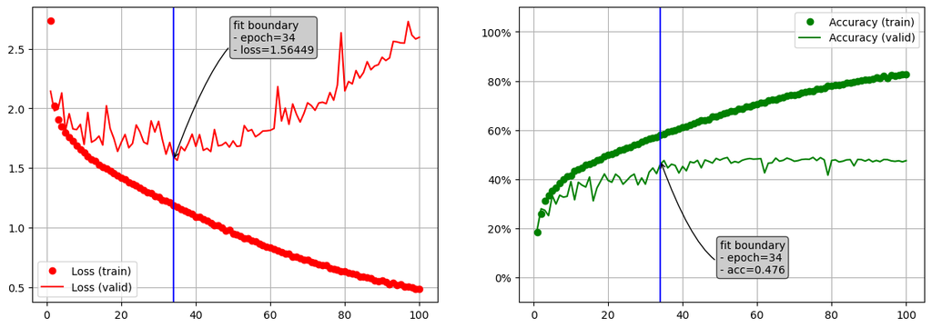

```python
plot_history(
    Experiment(train_hyperparams)
    .with_preprocessor(preprocessing_fn)
    .with_train_data(get_training_data())
    .with_valid_data(get_validation_data())
    .with_model(
        ModelBuilder(input_dims=ds_image_dims, n_classes=ds_classes)
        .add_layer(512, activation="relu")
        .add_layer(512, activation="relu")
        .build()
    )
    .run()
)
```

### Model 3: 1024 Units Per Layer

```
Model: "sequential_3"
_________________________________________________________________
 Layer (type)                Output Shape              Param #
=================================================================
 x0 (Dense)                  (None, 1024)              3146752

 x1 (Dense)                  (None, 1024)              1049600

 y_hat (Dense)               (None, 10)                10250

=================================================================
Total params: 4206602 (16.05 MB)
Trainable params: 4206602 (16.05 MB)
Non-trainable params: 0 (0.00 Byte)
_________________________________________________________________
```

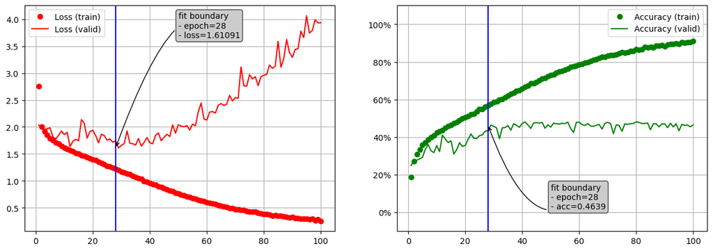

```python
plot_history(
    Experiment(train_hyperparams)
    .with_preprocessor(preprocessing_fn)
    .with_train_data(get_training_data())
    .with_valid_data(get_validation_data())
    .with_model(
        ModelBuilder(input_dims=ds_image_dims, n_classes=ds_classes)
        .add_layer(1024, activation="relu")
        .add_layer(1024, activation="relu")
        .build()
    )
    .run()
)
```

### Model 4: 2048 Units Per Layer

```python
plot_history(
    Experiment(train_hyperparams)
    .with_preprocessor(preprocessing_fn)
    .with_train_data(get_training_data())
    .with_valid_data(get_validation_data())
    .with_model(
        ModelBuilder(input_dims=ds_image_dims, n_classes=ds_classes)
        .add_layer(2048, activation="relu")
        .add_layer(2048, activation="relu")
        .build()
    )
    .run()
)
```

[output not shown]

### Model 5: 4096 Units Per Layer

```python
plot_history(
    Experiment(train_hyperparams)
    .with_preprocessor(preprocessing_fn)
    .with_train_data(get_training_data())
    .with_valid_data(get_validation_data())
    .with_model(
        ModelBuilder(input_dims=ds_image_dims, n_classes=ds_classes)
        .add_layer(4096, activation="relu")
        .add_layer(4096, activation="relu")
        .build()
    )
    .run()
)
```

[output not shown]

### 7. Regularization and Model Tuning

In the model tuning step of the Universal Workflow, we aim to optimize model performance by carefully adjusting various aspects of the model. This involves understanding the boundaries set by the Baseline Model and the largest Overfitting Model, and then implementing changes to mitigate overfitting while maintaining high accuracy.

1. Model Capacity (Layers and Units):
- Adjusting the number of layers and units in the model impacts the complexity of the learned function.
- A model with too few layers or units may underfit, while a model with too many may overfit.
- The goal is to find the right balance where the model's capacity is sufficient to capture the underlying patterns in the data without memorizing noise.
1. Layer Regularization:
- Regularization techniques such as L2 regularization penalize large coefficients (weights and biases), promoting smoother transitions between layers.
- By reducing the complexity of the learned function, regularization helps prevent overfitting to the training data.
1. Layer Dropout:
- Dropout is a regularization technique where random perceptrons are disabled during training.
- This prevents any single perceptron from becoming overly influential, leading to more robust representations.
- Adjusting the dropout rate introduces a regularization effect on the network, mitigating overfitting.
1. Hyperparameter Tuning:
- Changing the model architecture affects the parameter search space, necessitating updates to hyperparameters.
- Hyperparameter tuning involves adjusting parameters such as the learning rate (α) to optimize the training process.
- Proper tuning helps the model navigate the parameter space effectively, avoiding local minima and achieving better accuracy.

The following consequences are expected:

- Reduced capacity, regularisation, dropout may all lead to drop in training accuracy demonstrating that the ability of the model to learn from the input is reduced.Training accuracy must then be returned to as close as possible to the Overfitting Model;
- As soon as regularisation starts working, overfitting to the training data is postponed to later epochs. This might require the training to be extended over more epochs. However the loss for both train and valid start converging for longer, allowing the valid accuracy to increase at the same time that the train accuracy increases at a slower rate.
- Finally, the exploration of the parameter search surface requires the adjustment of the 𝛼 (or, "learning rate"), which will cause the gradient descent to avoid local minima while pursuing deeper minima that produce better accuracy.

The table below presents the results of such exploration:

| batch | epochs | optimizer | $\alpha$ | L1(u) | L1(a) | L1(r) | L1(d) | L2(u) | L2(a) | L2(r) | L2(d) | fit/epoch | fit/acc(valid) |
| --- | --- | --- | --- | --- | --- | --- | --- | --- | --- | --- | --- | --- | --- |
| 512 | 100 | rmsprop | 0.001 | 2048 | relu | - | - | - | - | - | - | 27 | 46.44% |
| 512 | 100 | rmsprop | 0.001 | 2048 | relu | l2 | - | - | - | - | - | 93 | 38.15% |
| 512 | 100 | rmsprop | 0.001 | 2048 | relu |  | 50% | - | - | - | - | 92 | 49.80% |
| 512 | 100 | rmsprop | 0.001 | 2048 | relu | l2 | 50% | - | - | - | - | 94 | 32.63% |
| 512 | 100 | rmsprop | 0.001 | 2048 | relu | l2 | - | 2048 | relu | l2 | - | 98 | 36.89% |
| 512 | 100 | rmsprop | 0.001 | 2048 | relu | - | 50% | 2048 | relu | - | 50% | 95 | 43.63% |
| 512 | 100 | rmsprop | 0.001 | 2048 | relu | l2 | 50% | 2048 | relu | l2 | 50% | 9 | 26.39% |
| 512 | 100 | rmsprop | 0.001 | 2048 | relu | l2 | 20% | 2048 | relu | l2 | 20% | 54 | 33.85% |
| 512 | 100 | adam | 0.001 | 2048 | relu | l2 | 20% | 2048 | relu | l2 | 20% | 45 | 42.39% |
| 512 | 100 | adam | 0.01 | 2048 | relu | l2 | 20% | 2048 | relu | l2 | 20% | 80 | 25.65% |
| 512 | 100 | adam | 0.0001 | 2048 | relu | l2 | 20% | 2048 | relu | l2 | 20% | 99 | 50.45% |
| 512 | 225 | adam | 0.0001 | 2048 | relu | l2 | 20% | 2048 | relu | l2 | 20% | 195 | 53.58% |
| 512 | 200 | adam | 0.0001 | 4096 | relu | l2 | 20% | 4096 | relu | l2 | 20% | 172 | 53.32% |
| 512 | 100 | adadelta | 0.001 | 2048 | relu | l2 | 20% | 2048 | relu | l2 | 20% | 99 | 38.44% |
| 512 | 225 | adadelta | 0.001 | 2048 | relu | l2 | 20% | 2048 | relu | l2 | 20% | 224 | 41.31% |

### 7.1 Model Capacity Adjustment

Adjusting the number of layers and units in the model impacts the complexity of the learned function. We evaluate the training history of models with different capacities to find the optimal balance between underfitting and overfitting.

### Basic Model without Regularization or Dropout

The model architecture consists of a single layer with 2048 units and ReLU activation function. No regularization methods, such as L1 or L2 regularization, are applied to the model parameters, and no dropout is used.

```python
plot_history(
    Experiment(train_hyperparams)
    .with_preprocessor(preprocessing_fn)
    .with_train_data(get_training_data())
    .with_valid_data(get_validation_data())
    .with_model(
        ModelBuilder(input_dims=ds_image_dims, n_classes=ds_classes)
        .add_layer(2048, activation="relu")
        .build()
    )
    .run()
)
```

[output not shown]

### Regularized Model with L2 Regularization

Incorporating L2 regularization into the model involves applying a penalty on the model parameters to prevent overfitting. The single-layer model with 2048 units and ReLU activation function now includes L2 regularization.

```python
plot_history(
    Experiment(train_hyperparams)
    .with_preprocessor(preprocessing_fn)
    .with_train_data(get_training_data())
    .with_valid_data(get_validation_data())
    .with_model(
        ModelBuilder(input_dims=ds_image_dims, n_classes=ds_classes)
        .add_layer(2048, activation="relu", regularization="l2")
        .build()
    )
    .run()
)
```

[output not shown]

### L2 Regularization On Multiple Layers

Extending regularization to multiple layers enhances the model's ability to generalize by penalizing large coefficients across multiple layers. Here, we introduce L2 regularization to two hidden layers, each containing 2048 units and ReLU activation function.

```python
plot_history(
    Experiment(train_hyperparams)
    .with_preprocessor(preprocessing_fn)
    .with_train_data(get_training_data())
    .with_valid_data(get_validation_data())
    .with_model(
        ModelBuilder(input_dims=ds_image_dims, n_classes=ds_classes)
        .add_layer(2048, activation="relu", regularization="l2")
        .add_layer(2048, activation="relu", regularization="l2")
        .build()
    )
    .run()
)
```

[output not shown]

### Dropout Regularization

Dropout regularization is implemented to prevent overfitting by randomly disabling a fraction of neurons during training. A single hidden layer with 2048 units and ReLU activation function is augmented with dropout regularization at a rate of 0.5.

Dropout is a regularization technique used to prevent overfitting by randomly dropping out (setting to zero) a fraction of input units during training, which helps to reduce co-adaptation of neurons.

```python
plot_history(
    Experiment(train_hyperparams)
    .with_preprocessor(preprocessing_fn)
    .with_train_data(get_training_data())
    .with_valid_data(get_validation_data())
    .with_model(
        ModelBuilder(input_dims=ds_image_dims, n_classes=ds_classes)
        .add_layer(2048, activation="relu", dropout=0.5)
        .build()
    )
    .run()
)
```

[output not shown]

### Dropout Regularization on Multiple Layers

Expanding dropout regularization to multiple layers further enhances the model's robustness against overfitting. We apply dropout regularization with a rate of 0.5 to two hidden layers, each consisting of 2048 units and ReLU activation function.

```python
plot_history(
    Experiment(train_hyperparams)
    .with_preprocessor(preprocessing_fn)
    .with_train_data(get_training_data())
    .with_valid_data(get_validation_data())
    .with_model(
        ModelBuilder(input_dims=ds_image_dims, n_classes=ds_classes)
        .add_layer(2048, activation="relu", dropout=0.5)
        .add_layer(2048, activation="relu", dropout=0.5)
        .build()
    )
    .run()
)
```

[output not shown]

### Dropout and L2 Regularization

Combining dropout and L2 regularization introduces a comprehensive regularization strategy to the model. In this configuration, a single hidden layer with 2048 units and ReLU activation function undergoes both dropout regularization (rate of 0.5) and L2 regularization.

```python
plot_history(
    Experiment(train_hyperparams)
    .with_preprocessor(preprocessing_fn)
    .with_train_data(get_training_data())
    .with_valid_data(get_validation_data())
    .with_model(
        ModelBuilder(input_dims=ds_image_dims, n_classes=ds_classes)
        .add_layer(2048, activation="relu", regularization="l2", dropout=0.5)
        .build()
    )
    .run()
)
```

[output not shown]

### Dropout (Rate 0.5) and L2 Regularization on Multiple Layers

Similar to the previous configuration, dropout and L2 regularization are applied to two hidden layers with 2048 units each. This dual regularization strategy is extended across multiple layers to enhance model generalization.

```python
plot_history(
    Experiment(train_hyperparams)
    .with_preprocessor(preprocessing_fn)
    .with_train_data(get_training_data())
    .with_valid_data(get_validation_data())
    .with_model(
        ModelBuilder(input_dims=ds_image_dims, n_classes=ds_classes)
        .add_layer(2048, activation="relu", regularization="l2", dropout=0.5)
        .add_layer(2048, activation="relu", regularization="l2", dropout=0.5)
        .build()
    )
    .run()
)
```

[output not shown]

### Dropout (Rate 0.2) and L2 Regularization on Multiple Layers

```python
plot_history(
    Experiment(train_hyperparams)
    .with_preprocessor(preprocessing_fn)
    .with_train_data(get_training_data())
    .with_valid_data(get_validation_data())
    .with_model(
        ModelBuilder(input_dims=ds_image_dims, n_classes=ds_classes)
        .add_layer(2048, activation="relu", regularization="l2", dropout=0.2)
        .add_layer(2048, activation="relu", regularization="l2", dropout=0.2)
        .build()
    )
    .run()
)
```

[output not shown]

### 7.2 Hyperparameter Tuning

Changing model architecture affects the parameter search space, necessitating updates to hyperparameters such as the learning rate (α). We explore different hyperparameter configurations to optimize training process and model convergence.

### Dropout, L2 Regularization, and Adam Optimizer with Default Learning Rate

Exploring different hyperparameter configurations is vital for optimizing model convergence. Here, we visualize the training history of a model with two hidden layers, dropout regularization (rate of 0.2), L2 regularization, and the Adam optimizer with default learning rate.

```python
plot_history(
    Experiment(train_hyperparams)
    .with_preprocessor(preprocessing_fn)
    .with_train_data(get_training_data())
    .with_valid_data(get_validation_data())
    .with_model(
        ModelBuilder(input_dims=ds_image_dims, n_classes=ds_classes)
        .with_optimizer("adam")
        .add_layer(2048, activation="relu", regularization="l2", dropout=0.2)
        .add_layer(2048, activation="relu", regularization="l2", dropout=0.2)
        .build()
    )
    .run()
)
```

[output not shown]

### Custom Learning Rate (0.01) and Dropout, L2 Regularization, and Adam Optimizer

Customizing the learning rate of the Adam optimizer allows for fine-grained control over the training process. This configuration employs a custom learning rate of 0.01 alongside dropout and L2 regularization in a model with two hidden layers.

```python
plot_history(
    Experiment(train_hyperparams)
    .with_preprocessor(preprocessing_fn)
    .with_train_data(get_training_data())
    .with_valid_data(get_validation_data())
    .with_model(
        ModelBuilder(input_dims=ds_image_dims, n_classes=ds_classes)
        .with_optimizer(optimizers.Adam(learning_rate=0.01))
        .add_layer(2048, activation="relu", regularization="l2", dropout=0.2)
        .add_layer(2048, activation="relu", regularization="l2", dropout=0.2)
        .build()
    )
    .run()
)
```

[output not shown]

### Custom Learning Rate (0.0001) and Dropout, L2 Regularization, and Adam Optimizer

Further fine-tuning the learning rate to 0.0001 demonstrates the impact of subtle changes in hyperparameters on model convergence. This configuration explores a lower learning rate while maintaining dropout and L2 regularization in a two-layer model.

```python
plot_history(
    Experiment(train_hyperparams)
    .with_preprocessor(preprocessing_fn)
    .with_train_data(get_training_data())
    .with_valid_data(get_validation_data())
    .with_model(
        ModelBuilder(input_dims=ds_image_dims, n_classes=ds_classes)
        .with_optimizer(optimizers.Adam(learning_rate=0.0001))
        .add_layer(2048, activation="relu", regularization="l2", dropout=0.2)
        .add_layer(2048, activation="relu", regularization="l2", dropout=0.2)
        .build()
    )
    .run()
)
```

[output not shown]

### Custom Optimizer (Adadelta) and Dropout Regularization

Diversifying optimizer choices can lead to different convergence behaviors and model performance. Here, we utilize the Adadelta optimizer alongside dropout regularization in a model with two hidden layers to explore alternative optimization strategies.

```python
# https://github.com/adhishthite/cifar10-optimizers
plot_history(
    Experiment(train_hyperparams, epochs=225)
    .with_preprocessor(preprocessing_fn)
    .with_train_data(get_training_data())
    .with_valid_data(get_validation_data())
    .with_model(
        ModelBuilder(input_dims=ds_image_dims, n_classes=ds_classes)
        .with_optimizer("adadelta")
        .add_layer(2048, activation="relu", regularization="l2", dropout=0.2)
        .add_layer(2048, activation="relu", regularization="l2", dropout=0.2)
        .build()
    )
    .run()
)
```

[output not shown]

### Custom Optimizer (Adadelta) and Dropout Regularization

```python
# https://github.com/adhishthite/cifar10-optimizers
plot_history(
    Experiment(train_hyperparams)
    .with_preprocessor(preprocessing_fn)
    .with_train_data(get_training_data())
    .with_valid_data(get_validation_data())
    .with_model(
        ModelBuilder(input_dims=ds_image_dims, n_classes=ds_classes)
        .with_optimizer("adadelta")
        .add_layer(2048, activation="relu", regularization="l2", dropout=0.2)
        .add_layer(2048, activation="relu", regularization="l2", dropout=0.2)
        .build()
    )
    .run()
)
```

[output not shown]

### 7.3 Extended Training and Optimization

Extends the training duration and explores deeper model architectures to further optimize model performance.

### Extended Epochs and Custom Adam Optimizer

Extending the training duration to 225 epochs allows for deeper exploration of the model's convergence behavior. This configuration employs the Adam optimizer with a custom learning rate of 0.0001 in a two-layer model with dropout and L2 regularization.

```python
plot_history(
    Experiment(train_hyperparams, epochs=225)
    .with_preprocessor(preprocessing_fn)
    .with_train_data(get_training_data())
    .with_valid_data(get_validation_data())
    .with_model(
        ModelBuilder(input_dims=ds_image_dims, n_classes=ds_classes)
        .with_optimizer(optimizers.Adam(learning_rate=0.0001))
        .add_layer(2048, activation="relu", regularization="l2", dropout=0.2)
        .add_layer(2048, activation="relu", regularization="l2", dropout=0.2)
        .build()
    )
    .run()
)
```

[output not shown]

### Custom Epochs and Optimizer

Adjusting the number of epochs to 200 provides insights into the model's convergence within a finite training window. This configuration utilizes the Adam optimizer with a custom learning rate of 0.0001 in a model with increased capacity, consisting of two hidden layers with 4096 units each.

```python
plot_history(
    Experiment(train_hyperparams, epochs=200)
    .with_preprocessor(preprocessing_fn)
    .with_train_data(get_training_data())
    .with_valid_data(get_validation_data())
    .with_model(
        ModelBuilder(input_dims=ds_image_dims, n_classes=ds_classes)
        .with_optimizer(optimizers.Adam(learning_rate=0.0001))
        .add_layer(4096, activation="relu", regularization="l2", dropout=0.2)
        .add_layer(4096, activation="relu", regularization="l2", dropout=0.2)
        .build()
    )
    .run()
)
```

[output not shown]

### Interpretation Of Results

Let's analyze the findings,

### RMSprop Optimizer:

Models trained with the RMSprop optimizer at a learning rate (𝛼) of 0.001 exhibit varying validation accuracies.

Without any regularization (L1 or L2) or dropout, the validation accuracy stands at 46.44% for a single-layer model with 2048 units and ReLU activation.

### Adam Optimizer:

Models trained with the Adam optimizer demonstrate improved validation accuracies compared to RMSprop.

Increasing the number of epochs from 100 to 225 further improves the validation accuracy to 53.58%.

### Effect of Model Capacity and Regularization:

Increasing model capacity by doubling the number of units to 4096 under Adam optimizer and L2 regularization leads to a validation accuracy of 53.32%.

### Hyperparameter Tuning with Adam Optimizer:

Tuning hyperparameters like the learning rate can significantly impact model performance. A higher learning rate of 0.01 results in a validation accuracy of 25.65%, while a lower learning rate of 0.0001 yields better performance with accuracies exceeding 50%.

### Comparison with Adadelta Optimizer:

Models trained with the Adadelta optimizer generally exhibit lower validation accuracies compared to Adam, even with the same hyperparameters and regularization settings.

For instance, with 225 epochs and L2 regularization, Adam achieves a validation accuracy of 53.58%, whereas Adadelta achieves 41.31%.

In summary, the validation accuracies vary across different configurations, indicating the importance of hyperparameter tuning, regularization techniques, and choice of optimizer in deep learning model training. Models with lower learning rates, appropriate regularization, and sufficient capacity tend to achieve higher validation accuracies, highlighting the significance of careful experimentation and optimization in model development.

### 8. Final Model

The Final Model stands as the pinnacle of our endeavor to strike an optimal balance between model complexity, performance, and computational efficiency. Through a meticulous process of exploration, experimentation, and fine-tuning, we have arrived at a model architecture that demonstrates promising performance on the CIFAR-10 dataset while ensuring generalization to unseen data.

### Model Selection Procedure

The journey towards the Final Model commenced with the selection of the best architecture and hyperparameters. After exhaustive experimentation, a model architecture comprising two hidden layers, each housing 2048 units with ReLU activation function, L2 regularization, and a dropout rate of 20% emerged as the most effective configuration. This architecture was chosen based on its ability to strike a balance between model complexity and performance.

### Results and Performance Evaluation

Evaluation on Hold-out CIFAR-10 Test Dataset: Following training, the Final Model's performance was evaluated against the hold-out CIFAR-10 test dataset to assess its generalization ability.

### Results

The present work experimented upon all these following models:

[output not shown]

The Best Model, designated as the **Final Model** found was the following:

| batch | epochs | optimizer | $\alpha$ | L1(u) | L1(a) | L1(r) | L1(d) | L2(u) | L2(a) | L2(r) | L2(d) | fit/epoch | fit/acc(valid) |
| --- | --- | --- | --- | --- | --- | --- | --- | --- | --- | --- | --- | --- | --- |
| 512 | 225 | adam | 0.0001 | 2048 | relu | l2 | 20% | 2048 | relu | l2 | 20% | 195 | 53.58% |

### Implementation

The Final Model was implemented using the following code:

```python
final_dir = "/content/drive/MyDrive/Models/2023-02-25_CM3015_MLNN"

final_model = (
    ModelBuilder(input_dims=ds_image_dims, n_classes=ds_classes)
    .with_optimizer(optimizers.Adam(learning_rate=0.0001))
    .add_layer(2048, activation="relu", regularization="l2", dropout=0.2)
    .add_layer(2048, activation="relu", regularization="l2", dropout=0.2)
    .build()
)

final_history = (
    Experiment(train_hyperparams, epochs=195)
    .with_preprocessor(preprocessing_fn)
    .with_train_data(get_training_and_validation_data())
    .with_model(final_model)
    .enable_log_tensorboard(os.path.join(final_dir, "logs/tensorboard"))
    .enable_log_csv(os.path.join(final_dir, "logs/training/final_model.csv"))
    .run()
)

# final_model.save(os.path.join(final_dir, "saved_model"))
final_model = models.load_model(os.path.join(final_dir, "saved_model"))


final_model.evaluate(get_test_data().map(preprocessing_fn).cache().batch(512))
```

```
Model: "sequential_3"
_________________________________________________________________
 Layer (type)                Output Shape              Param #
=================================================================
 x0 (Dense)                  (None, 2048)              6293504

 dropout_2 (Dropout)         (None, 2048)              0

 x1 (Dense)                  (None, 2048)              4196352

 dropout_3 (Dropout)         (None, 2048)              0

 y_hat (Dense)               (None, 10)                20490

=================================================================
Total params: 10510346 (40.09 MB)
Trainable params: 10510346 (40.09 MB)
Non-trainable params: 0 (0.00 Byte)
_________________________________________________________________
```

[output not shown]

This implementation encapsulates the model architecture, training process, and evaluation metrics, providing a comprehensive framework for reproducibility and further experimentation.

### Recommendations for Future Research:

1. Utilization of Convolutional Layers: Integration of convolutional layers into the model architecture could address limitations associated with densely connected layers, potentially improving accuracy, especially in scenarios with limited datasets.
2. Data Augmentation: Augmenting training data through techniques such as mirroring, rotation, and cropping holds the potential to enhance the representativeness of high-level features, thereby improving model performance, particularly in recognizing complex patterns.
3. Further Exploration with Adadelta: Despite its challenges in convergence, allowing the Adadelta optimizer to train until convergence, possibly with enhanced computing resources, may unveil its full potential in achieving deeper loss. However, the marginal gains in accuracy must be weighed against increased computational costs.

### 10. Conclusion

In conclusion, the Final Model represents a significant leap forward in model optimization and performance enhancement. While achieving commendable accuracy on the CIFAR-10 dataset, there remains ample room for further research and refinement. By leveraging advanced techniques such as convolutional layers and data augmentation, future models can strive for even greater accuracy and robustness in tackling complex tasks. Our journey underscores the iterative nature of model development, where each experiment and insight contributes to the collective understanding, paving the way for advancements in machine learning and artificial intelligence.